# Mobility - getting up from sitting down

# 1 Description of DataSchema variable

The description of harmonised variable is the following:

- Short name: `mob_up`
- Variable label: `Difficulty for getting up from sitting down`
- Variable description: `Difficulty for getting up from sitting down`
- Domain: `Health status and functional limitations`
- Value type: `categorical`
- Category coding:

| **Code** | **Category Label** |
| --- | --- |
| 0 | Yes |
| 1 | No |

- Category missings:

| **Code** | **Category Label** |
| --- | --- |
| 991 | CAPI/interviewer error |
| 992 | Impute |
| 993 | Disable to measure |
| 994 | Not attempt/not done |
| 995 | Does not answer |
| 996 | Not applicable |
| 997 | Refuse |
| 998 | Do not know |
| 999 | Missing |

# 2 Data process

## 2.1 England

### 2.1.1 Wave 1

#### 2.1.1.1 Study-specific variable description

| **Name** | `hemobch` |
| --- | --- |
| **Label** | `Difficulty getting up from chair after sitting long periods` |
| **Table name** | `wave_1_ifs_derived_variables` |
| **Categories** | `0 = No; 1 = Yes` |
| **Missings** | `-9 = Refusal; -8 = Don't Know; -1 = Not applicable` |
| **Description** |  |

hemobch

| Sample size | Missing values |
| --- | --- |
| 12099 | 191 |

Category

|  | 0 | 1 |
| --- | --- | --- |
| Frequency | 8858.00 | 3050.00 |
| Percentage | 73.21 | 25.21 |

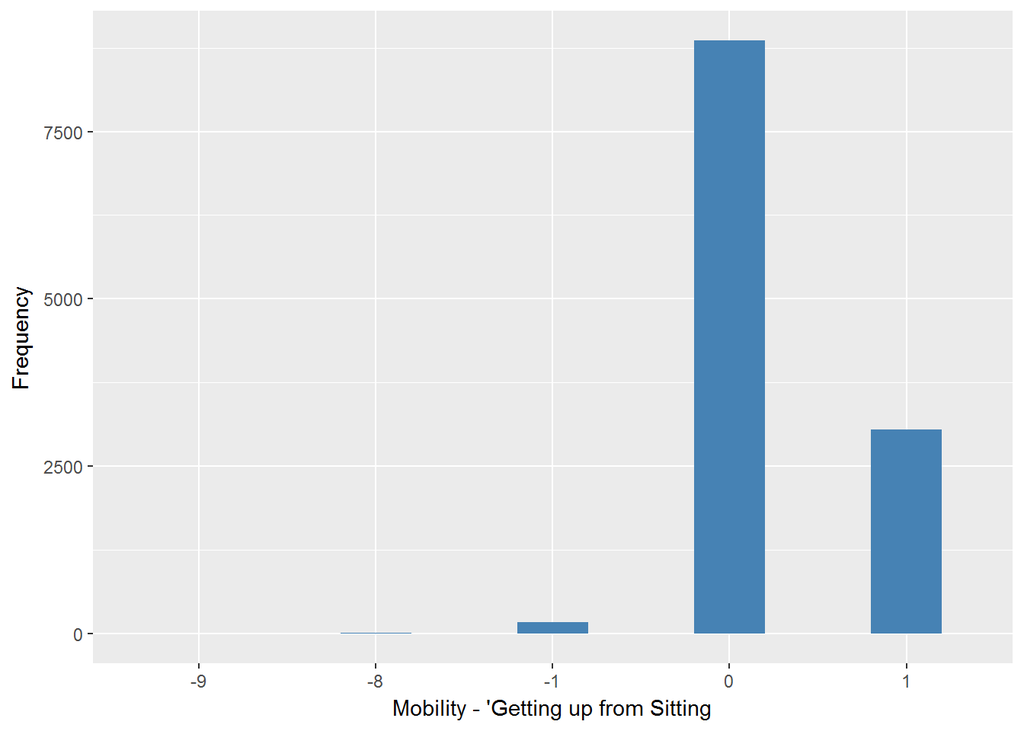

#### 2.1.1.2 Harmonisation algorithm

To compute the harmonize variable from the study-specific variable it has to be recoded as follows:

- `1 into 0`
- `0 into 1`
- `-9 Refusal into 997`
- `-8 Don't know into 998`
- `-1 Not applicable into 996`

**R script:**

```r
ELSA_ds_w1 <- tibble(id = ELSA_w1_mob_up$id)
ELSA_ds_w1$mob_up <- car::recode(ELSA_w1_mob_up$hemobch, "0 = '1';1 = '0';-9 = '997';-8 = '998';-1 = '996' ")
ELSA_ds_w1$mob_up <- labelled(ELSA_ds_w1$mob_up, labels = c(Yes = 0, No = 1,
    Missing = 999, Do_not_know = 998, Refuse = 997, Not_applicable = 996, Does_not_answer = 995,
    Not_attempt_not_done = 994, Disable_to_measure = 993, Impute = 992, CAPI_interviewer_error = 991))
```

#### 2.1.1.3 Statistical description of the new harmonised variable

mob_up

| Sample size | Missing values |
| --- | --- |
| 12099 | 191 |

Category

|  | 0 | 1 |
| --- | --- | --- |
| Frequency | 3050.00 | 8858.00 |
| Percentage | 25.21 | 73.21 |

Type of missing

|  | 991 | 992 | 993 | 994 | 995 | 996 | 997 | 998 | 999 | NA |
| --- | --- | --- | --- | --- | --- | --- | --- | --- | --- | --- |
| Frequency | 0 | 0 | 0 | 0 | 0 | 175.00 | 4.00 | 12.0 | 0 | 0 |
| Percentage | 0 | 0 | 0 | 0 | 0 | 1.45 | 0.03 | 0.1 | 0 | 0 |

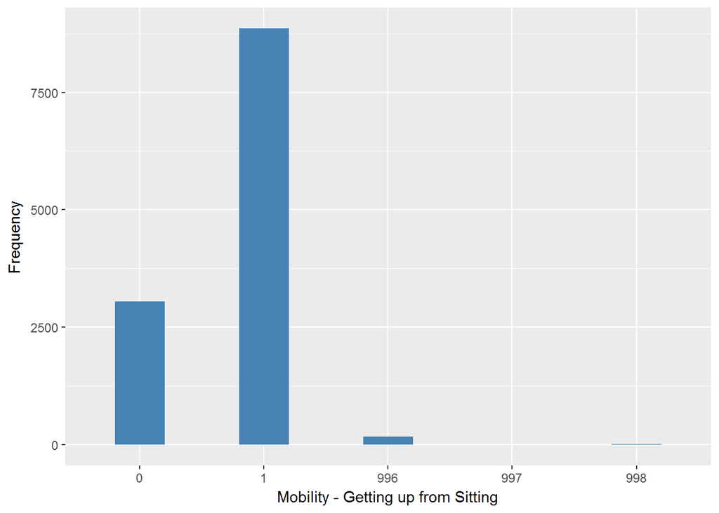

#### 2.1.1.4 Validation

|  | 1->0 | 0->1 | -1->996 | -9->997 | -8->998 |
| --- | --- | --- | --- | --- | --- |
| BeforeH | 3050 | 8858 | 175 | 4 | 12 |
| AfterH | 3050 | 8858 | 175 | 4 | 12 |

### 2.1.2 Wave 2

#### 2.1.2.1 Study-specific variable description

| **Name** | `hemobch` |
| --- | --- |
| **Label** | `Difficulty getting up from chair after sitting long periods` |
| **Table name** | `wave_2_ifs_derived_variables` |
| **Categories** | `0 = No; 1 = Yes` |
| **Missings** | `-9 = Refusal; -8 = Don't Know` |
| **Description** |  |

hemobch

| Sample size | Missing values |
| --- | --- |
| 9432 | 3 |

Category

|  | 0 | 1 |
| --- | --- | --- |
| Frequency | 6916.00 | 2513.00 |
| Percentage | 73.32 | 26.64 |

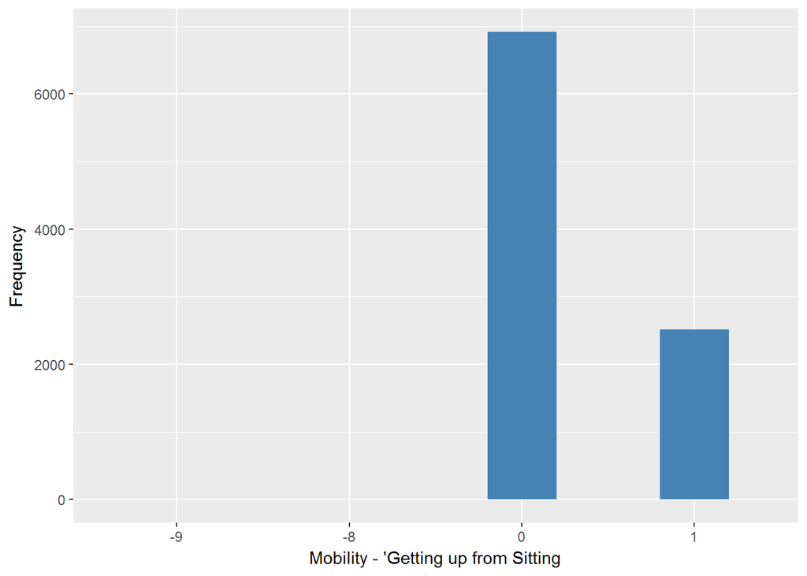

#### 2.1.2.2 Harmonisation algorithm

To compute the harmonize variable from the study-specific variable it has to be recoded as follows:

- `1 into 0`
- `0 into 1`
- `-9 Refusal into 997`
- `-8 Don't know into 998`

**R script:**

```r
ELSA_ds_w2 <- tibble(id = ELSA_w2_mob_up$id)
ELSA_ds_w2$mob_up <- car::recode(ELSA_w2_mob_up$hemobch, "0 = '1';1 = '0';-9 = '997';-8 = '998' ")
ELSA_ds_w2$mob_up <- labelled(ELSA_ds_w2$mob_up, labels = c(Yes = 0, No = 1,
    Missing = 999, Do_not_know = 998, Refuse = 997, Not_applicable = 996, Does_not_answer = 995,
    Not_attempt_not_done = 994, Disable_to_measure = 993, Impute = 992, CAPI_interviewer_error = 991))
```

#### 2.1.2.3 Statistical description of the new harmonised variable

mob_up

| Sample size | Missing values |
| --- | --- |
| 9432 | 3 |

Category

|  | 0 | 1 |
| --- | --- | --- |
| Frequency | 2513.00 | 6916.00 |
| Percentage | 26.64 | 73.32 |

Type of missing

|  | 991 | 992 | 993 | 994 | 995 | 996 | 997 | 998 | 999 | NA |
| --- | --- | --- | --- | --- | --- | --- | --- | --- | --- | --- |
| Frequency | 0 | 0 | 0 | 0 | 0 | 0 | 1.00 | 2.00 | 0 | 0 |
| Percentage | 0 | 0 | 0 | 0 | 0 | 0 | 0.01 | 0.02 | 0 | 0 |

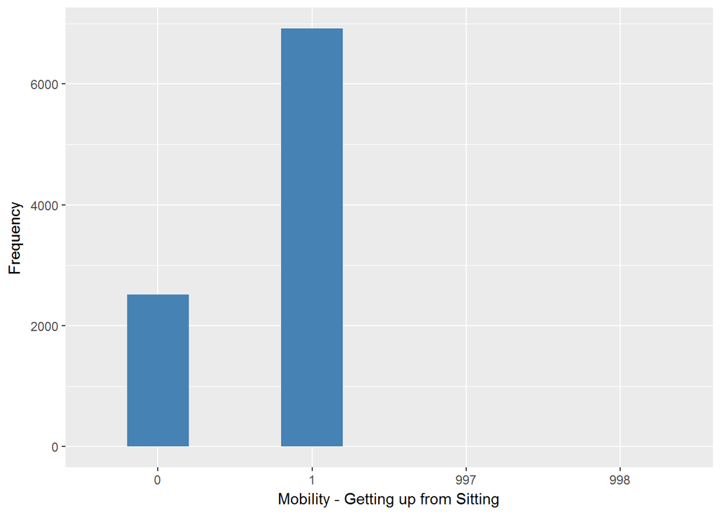

#### 2.1.2.4 Validation

|  | 1->0 | 0->1 | -9->997 | -8->998 |
| --- | --- | --- | --- | --- |
| BeforeH | 2513 | 6916 | 1 | 2 |
| AfterH | 2513 | 6916 | 1 | 2 |

### 2.1.3 Wave 3

#### 2.1.3.1 Study-specific variable description

| **Name** | `hemobch` |
| --- | --- |
| **Label** | `Difficulty getting up from chair after sitting long periods` |
| **Table name** | `wave_3_elsa_data_v4` |
| **Categories** | `0 = No; 1 = Yes` |
| **Missings** | `-1 = Not applicable` |
| **Description** |  |

hemobch

| Sample size | Missing values |
| --- | --- |
| 9771 | 4 |

Category

|  | 0 | 1 |
| --- | --- | --- |
| Frequency | 7324.00 | 2443 |
| Percentage | 74.96 | 25 |

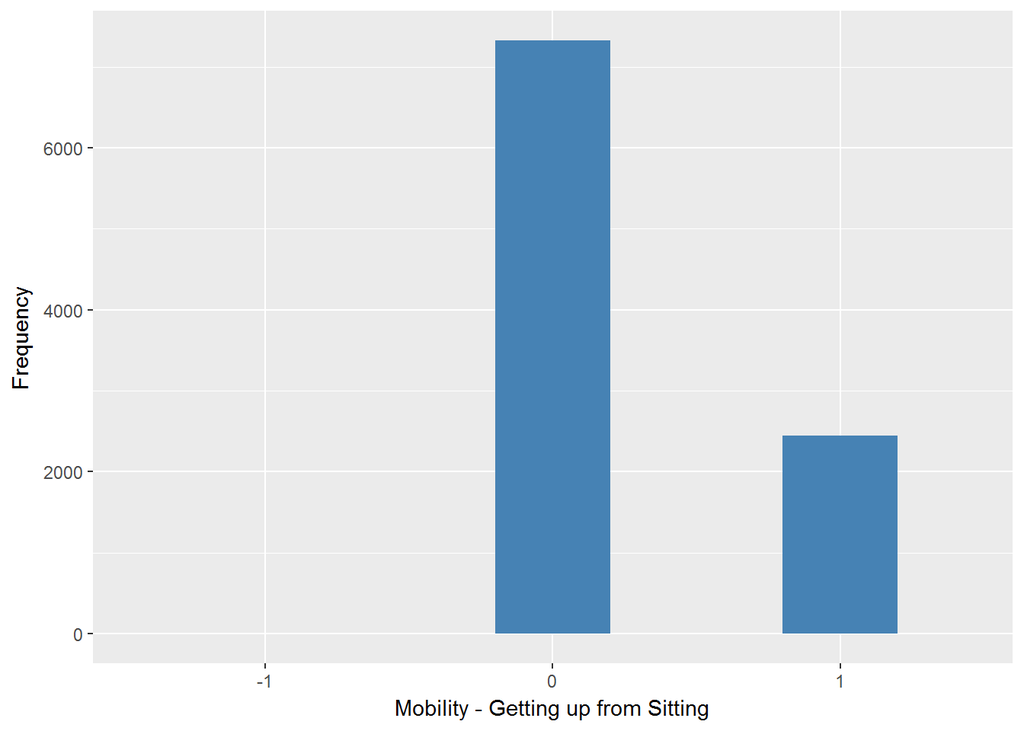

#### 2.1.3.2 Harmonisation algorithm

To compute the harmonize variable from the study-specific variable it has to be recoded as follows:

- `1 into 0`
- `0 into 1`
- `-1 Not applicable into 996`

**R script:**

```r
ELSA_ds_w3 <- tibble(id = ELSA_w3_mob_up$id)
ELSA_ds_w3$mob_up <- car::recode(ELSA_w3_mob_up$hemobch, "0 = '1';1 = '0';-1 = '996' ")
ELSA_ds_w3$mob_up <- labelled(ELSA_ds_w3$mob_up, labels = c(Yes = 0, No = 1,
    Missing = 999, Do_not_know = 998, Refuse = 997, Not_applicable = 996, Does_not_answer = 995,
    Not_attempt_not_done = 994, Disable_to_measure = 993, Impute = 992, CAPI_interviewer_error = 991))
```

#### 2.1.3.3 Statistical description of the new harmonised variable

mob_up

| Sample size | Missing values |
| --- | --- |
| 9771 | 4 |

Category

|  | 0 | 1 |
| --- | --- | --- |
| Frequency | 2443 | 7324.00 |
| Percentage | 25 | 74.96 |

Type of missing

|  | 991 | 992 | 993 | 994 | 995 | 996 | 997 | 998 | 999 | NA |
| --- | --- | --- | --- | --- | --- | --- | --- | --- | --- | --- |
| Frequency | 0 | 0 | 0 | 0 | 0 | 4.00 | 0 | 0 | 0 | 0 |
| Percentage | 0 | 0 | 0 | 0 | 0 | 0.04 | 0 | 0 | 0 | 0 |

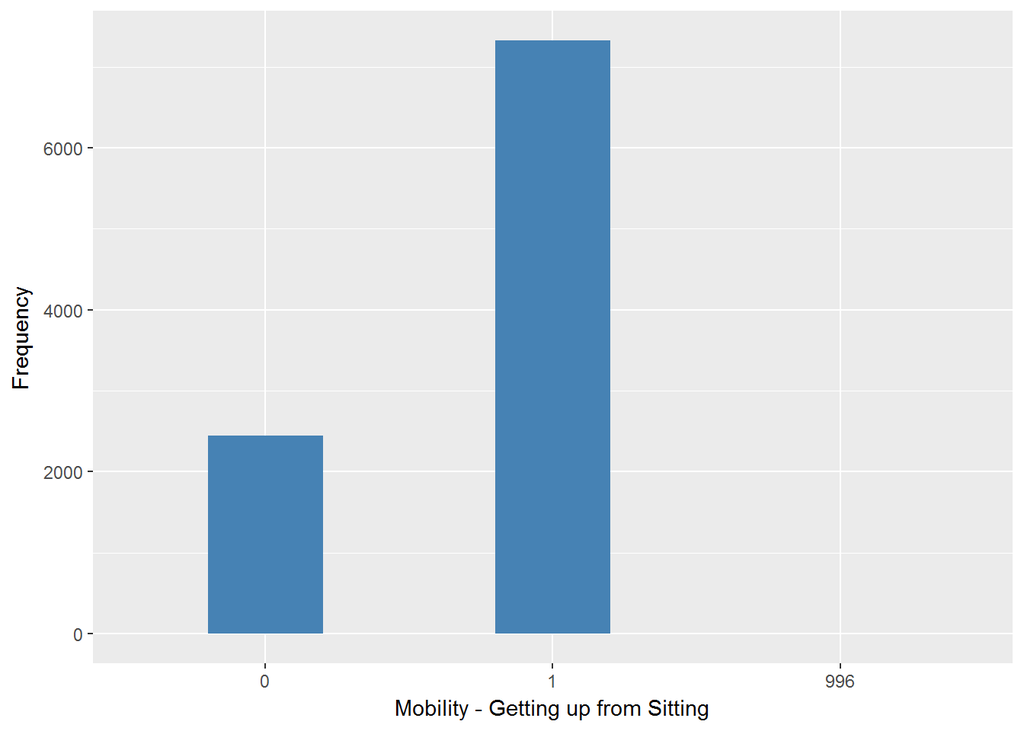

#### 2.1.3.4 Validation

|  | 0,1,2,3->0 | 4->1 | -1->996 |
| --- | --- | --- | --- |
| BeforeH | 2443 | 7324 | 4 |
| AfterH | 2443 | 7324 | 4 |

### 2.1.4 Wave 4

#### 2.1.4.1 Study-specific variable description

| **Name** | `hemobch` |
| --- | --- |
| **Label** | `Difficulty getting up from chair after sitting long periods` |
| **Table name** | `wave_4_elsa_data_v3` |
| **Categories** | `0 = No; 1 = Yes` |
| **Missings** | `-9 = Refusal; -8 = Don't Know` |
| **Description** |  |

hemobch

| Sample size | Missing values |
| --- | --- |
| 11050 | 10 |

Category

|  | 0 | 1 |
| --- | --- | --- |
| Frequency | 8330.00 | 2710.00 |
| Percentage | 75.38 | 24.52 |

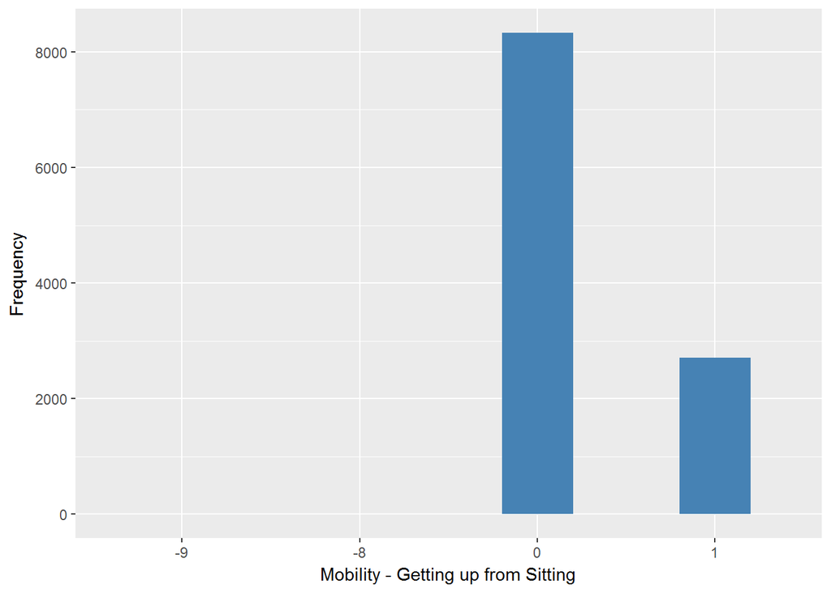

#### 2.1.4.2 Harmonisation algorithm

To compute the harmonize variable from the study-specific variable it has to be recoded as follows:

- `1 Yes into 0`
- `0 No into 1`
- `-9 Refusal into 997`
- `-8 Don't know into 998`

**R script:**

```r
ELSA_ds_w4 <- tibble(id = ELSA_w4_mob_up$id)
ELSA_ds_w4$mob_up <- car::recode(ELSA_w4_mob_up$hemobch, "0 = '1';1 = '0';-9 = '997';-8 = '998'")
ELSA_ds_w4$mob_up <- labelled(ELSA_ds_w4$mob_up, labels = c(Yes = 0, No = 1,
    Missing = 999, Do_not_know = 998, Refuse = 997, Not_applicable = 996, Does_not_answer = 995,
    Not_attempt_not_done = 994, Disable_to_measure = 993, Impute = 992, CAPI_interviewer_error = 991))
```

#### 2.1.4.3 Statistical description of the new harmonised variable

mob_up

| Sample size | Missing values |
| --- | --- |
| 11050 | 10 |

Category

|  | 0 | 1 |
| --- | --- | --- |
| Frequency | 2710.00 | 8330.00 |
| Percentage | 24.52 | 75.38 |

Type of missing

|  | 991 | 992 | 993 | 994 | 995 | 996 | 997 | 998 | 999 | NA |
| --- | --- | --- | --- | --- | --- | --- | --- | --- | --- | --- |
| Frequency | 0 | 0 | 0 | 0 | 0 | 0 | 7.00 | 3.00 | 0 | 0 |
| Percentage | 0 | 0 | 0 | 0 | 0 | 0 | 0.06 | 0.03 | 0 | 0 |

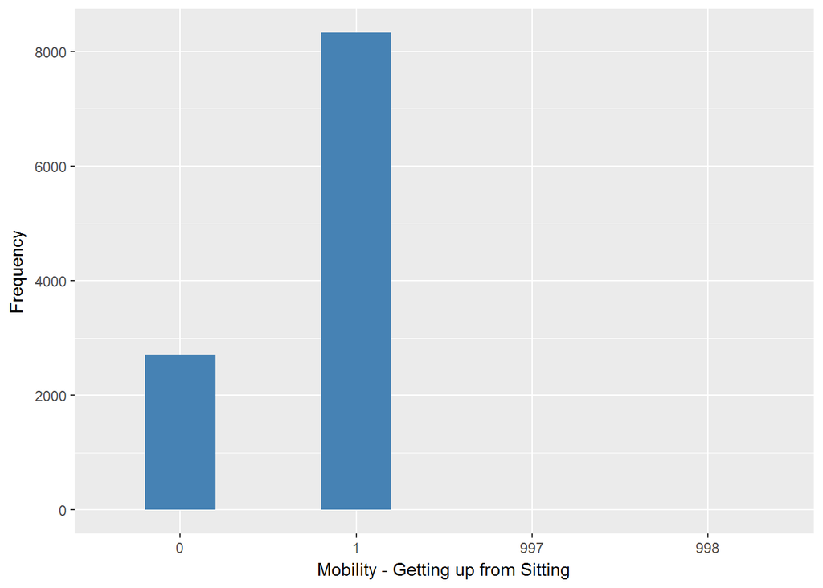

#### 2.1.4.4 Validation

|  | 1->0 | 1->0 | -9->997 | -8->998 |
| --- | --- | --- | --- | --- |
| BeforeH | 2710 | 8330 | 7 | 3 |
| AfterH | 2710 | 8330 | 7 | 3 |

### 2.1.5 Wave 5

#### 2.1.5.1 Study-specific variable description

| **Name** | `hemobch` |
| --- | --- |
| **Label** | `Difficulty getting up from chair after sitting long periods` |
| **Table name** | `wave_5_elsa_data_v4` |
| **Categories** | `0 = No; 1 = Yes` |
| **Missings** | `-9 = Refusal; -8 = Don't Know` |
| **Description** |  |

hemobch

| Sample size | Missing values |
| --- | --- |
| 10274 | 9 |

Category

|  | 0 | 1 |
| --- | --- | --- |
| Frequency | 7648.00 | 2617.00 |
| Percentage | 74.44 | 25.47 |

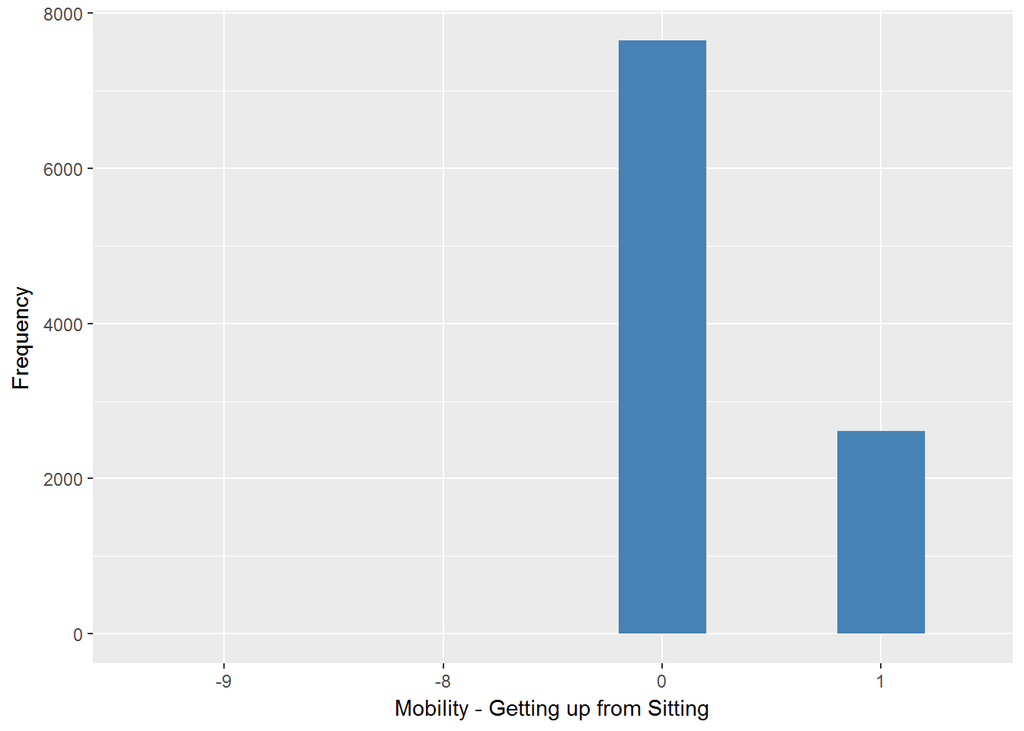

#### 2.1.5.2 Harmonisation algorithm

To compute the harmonize variable from the study-specific variable it has to be recoded as follows:

- `1 Yes into 0`
- `0 No into 1`
- `-9 Refusal into 997`
- `-8 Don't know into 998`

**R script:**

```r
ELSA_ds_w5 <- tibble(id = ELSA_w5_mob_up$id)
ELSA_ds_w5$mob_up <- car::recode(ELSA_w5_mob_up$hemobch, "0 = '1';1 = '0';-9 = '997';-8 = '998'")
ELSA_ds_w5$mob_up <- labelled(ELSA_ds_w5$mob_up, labels = c(Yes = 0, No = 1,
    Missing = 999, Do_not_know = 998, Refuse = 997, Not_applicable = 996, Does_not_answer = 995,
    Not_attempt_not_done = 994, Disable_to_measure = 993, Impute = 992, CAPI_interviewer_error = 991))
```

#### 2.1.5.3 Statistical description of the new harmonised variable

mob_up

| Sample size | Missing values |
| --- | --- |
| 10274 | 9 |

Category

|  | 0 | 1 |
| --- | --- | --- |
| Frequency | 2617.00 | 7648.00 |
| Percentage | 25.47 | 74.44 |

Type of missing

|  | 991 | 992 | 993 | 994 | 995 | 996 | 997 | 998 | 999 | NA |
| --- | --- | --- | --- | --- | --- | --- | --- | --- | --- | --- |
| Frequency | 0 | 0 | 0 | 0 | 0 | 0 | 6.00 | 3.00 | 0 | 0 |
| Percentage | 0 | 0 | 0 | 0 | 0 | 0 | 0.06 | 0.03 | 0 | 0 |

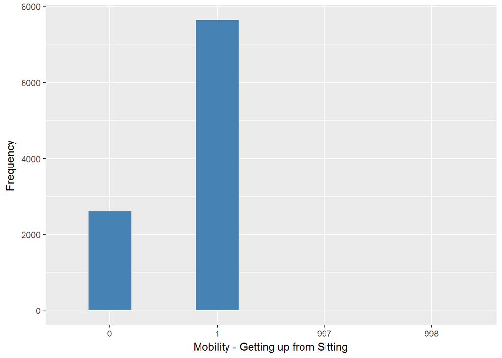

#### 2.1.5.4 Validation

|  | 1->0 | 1->0 | -9->997 | -8->998 |
| --- | --- | --- | --- | --- |
| BeforeH | 2617 | 7648 | 6 | 3 |
| AfterH | 2617 | 7648 | 6 | 3 |

### 2.1.6 Wave 6

#### 2.1.6.1 Study-specific variable description

| **Name** | `hemobch` |
| --- | --- |
| **Label** | `Difficulty getting up from chair after sitting long periods` |
| **Table name** | `wave_6_elsa_data_v2` |
| **Categories** | `0 = No; 1 = Yes` |
| **Missings** | `-9 = Refusal; -8 = Don't Know` |
| **Description** |  |

hemobch

| Sample size | Missing values |
| --- | --- |
| 10601 | 5 |

Category

|  | 0 | 1 |
| --- | --- | --- |
| Frequency | 8019.00 | 2577.00 |
| Percentage | 75.64 | 24.31 |

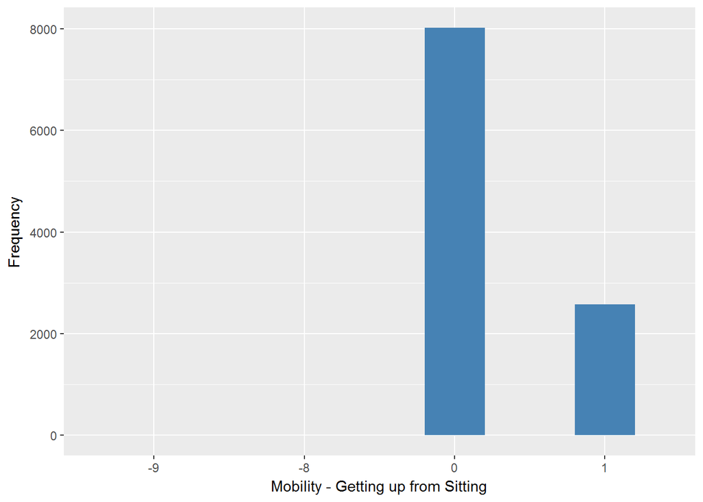

#### 2.1.6.2 Harmonisation algorithm

To compute the harmonize variable from the study-specific variable it has to be recoded as follows:

- `1 Yes into 0`
- `0 No into 1`
- `-9 Refusal into 997`
- `-8 Don't know into 998`

**R script:**

```r
ELSA_ds_w6 <- tibble(id = ELSA_w6_mob_up$id)
ELSA_ds_w6$mob_up <- car::recode(ELSA_w6_mob_up$hemobch, "0 = '1';1 = '0';-9 = '997';-8 = '998' ")
ELSA_ds_w6$mob_up <- labelled(ELSA_ds_w6$mob_up, labels = c(Yes = 0, No = 1,
    Missing = 999, Do_not_know = 998, Refuse = 997, Not_applicable = 996, Does_not_answer = 995,
    Not_attempt_not_done = 994, Disable_to_measure = 993, Impute = 992, CAPI_interviewer_error = 991))
```

#### 2.1.6.3 Statistical description of the new harmonised variable

mob_up

| Sample size | Missing values |
| --- | --- |
| 10601 | 5 |

Category

|  | 0 | 1 |
| --- | --- | --- |
| Frequency | 2577.00 | 8019.00 |
| Percentage | 24.31 | 75.64 |

Type of missing

|  | 991 | 992 | 993 | 994 | 995 | 996 | 997 | 998 | 999 | NA |
| --- | --- | --- | --- | --- | --- | --- | --- | --- | --- | --- |
| Frequency | 0 | 0 | 0 | 0 | 0 | 0 | 3.00 | 2.00 | 0 | 0 |
| Percentage | 0 | 0 | 0 | 0 | 0 | 0 | 0.03 | 0.02 | 0 | 0 |

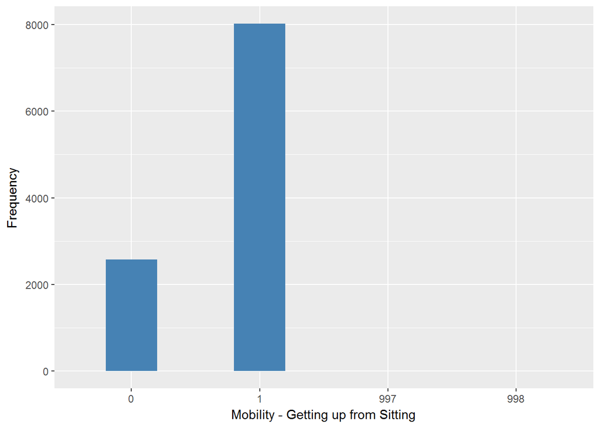

#### 2.1.6.4 Validation

|  | 1->0 | 1->0 | -9->997 | -8->998 |
| --- | --- | --- | --- | --- |
| BeforeH | 2577 | 8019 | 3 | 2 |
| AfterH | 2577 | 8019 | 3 | 2 |

### 2.1.7 Wave 7

#### 2.1.7.1 Study-specific variable description

| **Name** | `hemobch` |
| --- | --- |
| **Label** | `Difficulty getting up from chair after sitting long periods` |
| **Table name** | `wave_7_elsa_data` |
| **Categories** | `0 = No; 1 = Yes` |
| **Missings** | `-8 = Don't Know` |
| **Description** |  |

hemobch

| Sample size | Missing values |
| --- | --- |
| 9666 | 2 |

Category

|  | 0 | 1 |
| --- | --- | --- |
| Frequency | 7317.0 | 2347.00 |
| Percentage | 75.7 | 24.28 |

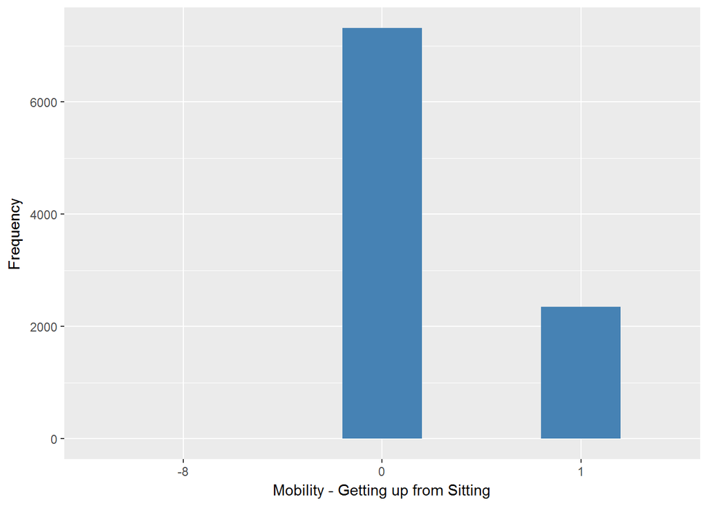

#### 2.1.7.2 Harmonisation algorithm

To compute the harmonize variable from the study-specific variable it has to be recoded as follows:

- `1 Yes into 0`
- `0 No into 1`
- `-8 Don't know into 998`

**R script:**

```r
ELSA_ds_w7 <- tibble(id = ELSA_w7_mob_up$id)
ELSA_ds_w7$mob_up <- car::recode(ELSA_w7_mob_up$hemobch, "0 = '1';1 = '0';-8 = '998' ")
ELSA_ds_w7$mob_up <- labelled(ELSA_ds_w7$mob_up, labels = c(Yes = 0, No = 1,
    Missing = 999, Do_not_know = 998, Refuse = 997, Not_applicable = 996, Does_not_answer = 995,
    Not_attempt_not_done = 994, Disable_to_measure = 993, Impute = 992, CAPI_interviewer_error = 991))
```

#### 2.1.7.3 Statistical description of the new harmonised variable

mob_up

| Sample size | Missing values |
| --- | --- |
| 9666 | 2 |

Category

|  | 0 | 1 |
| --- | --- | --- |
| Frequency | 2347.00 | 7317.0 |
| Percentage | 24.28 | 75.7 |

Type of missing

|  | 991 | 992 | 993 | 994 | 995 | 996 | 997 | 998 | 999 | NA |
| --- | --- | --- | --- | --- | --- | --- | --- | --- | --- | --- |
| Frequency | 0 | 0 | 0 | 0 | 0 | 0 | 0 | 2.00 | 0 | 0 |
| Percentage | 0 | 0 | 0 | 0 | 0 | 0 | 0 | 0.02 | 0 | 0 |

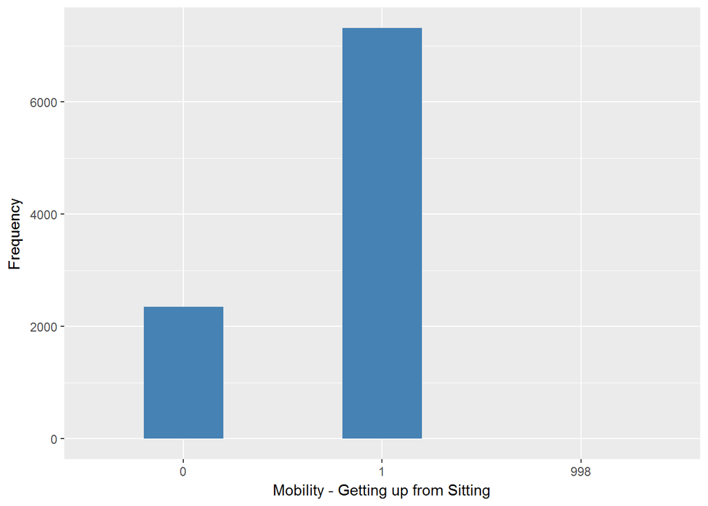

#### 2.1.7.4 Validation

|  | 1->0 | 1->0 | -8->998 |
| --- | --- | --- | --- |
| BeforeH | 2347 | 7317 | 2 |
| AfterH | 2347 | 7317 | 2 |

## 2.2 Summary of descriptive statistics of the harmonised variable accross populations and waves

Two tables are generated:

1. Percentages of categories in each harmonised variable.
2. Frequencies and percentages of individuals with different trajectories. To avoid too large table, Only trajectories with percentages larger than 0.3 are shown.

**R script:**

```r
ELSA_ds_w1$mob_up <- labelled(ELSA_ds_w1$mob_up, labels = c(Presence = 0, Absence = 1,
    Missing = 999, Do_not_know = 998, Refuse = 997, Not_applicable = 996, Does_not_answer = 995,
    Not_attempt_not_done = 994, Disable_to_measure = 993, Impute = 992, CAPI_interviewer_error = 991))
ELSA_ds_w2$mob_up <- labelled(ELSA_ds_w2$mob_up, labels = c(Presence = 0, Absence = 1,
    Missing = 999, Do_not_know = 998, Refuse = 997, Not_applicable = 996, Does_not_answer = 995,
    Not_attempt_not_done = 994, Disable_to_measure = 993, Impute = 992, CAPI_interviewer_error = 991))
ELSA_ds_w3$mob_up <- labelled(ELSA_ds_w3$mob_up, labels = c(Presence = 0, Absence = 1,
    Missing = 999, Do_not_know = 998, Refuse = 997, Not_applicable = 996, Does_not_answer = 995,
    Not_attempt_not_done = 994, Disable_to_measure = 993, Impute = 992, CAPI_interviewer_error = 991))
ELSA_ds_w4$mob_up <- labelled(ELSA_ds_w4$mob_up, labels = c(Presence = 0, Absence = 1,
    Missing = 999, Do_not_know = 998, Refuse = 997, Not_applicable = 996, Does_not_answer = 995,
    Not_attempt_not_done = 994, Disable_to_measure = 993, Impute = 992, CAPI_interviewer_error = 991))
ELSA_ds_w5$mob_up <- labelled(ELSA_ds_w5$mob_up, labels = c(Presence = 0, Absence = 1,
    Missing = 999, Do_not_know = 998, Refuse = 997, Not_applicable = 996, Does_not_answer = 995,
    Not_attempt_not_done = 994, Disable_to_measure = 993, Impute = 992, CAPI_interviewer_error = 991))
ELSA_ds_w6$mob_up <- labelled(ELSA_ds_w6$mob_up, labels = c(Presence = 0, Absence = 1,
    Missing = 999, Do_not_know = 998, Refuse = 997, Not_applicable = 996, Does_not_answer = 995,
    Not_attempt_not_done = 994, Disable_to_measure = 993, Impute = 992, CAPI_interviewer_error = 991))
ELSA_ds_w7$mob_up <- labelled(ELSA_ds_w7$mob_up, labels = c(Presence = 0, Absence = 1,
    Missing = 999, Do_not_know = 998, Refuse = 997, Not_applicable = 996, Does_not_answer = 995,
    Not_attempt_not_done = 994, Disable_to_measure = 993, Impute = 992, CAPI_interviewer_error = 991))

tt <- frq(ELSA_ds_w1$mob_up)[[1]][, c(1:2, 4)]
tt[4] <- frq(ELSA_ds_w2$mob_up)[[1]][, c(4)]
tt[5] <- frq(ELSA_ds_w3$mob_up)[[1]][, c(4)]
tt[6] <- frq(ELSA_ds_w4$mob_up)[[1]][, c(4)]
tt[7] <- frq(ELSA_ds_w5$mob_up)[[1]][, c(4)]
tt[8] <- frq(ELSA_ds_w6$mob_up)[[1]][, c(4)]
tt[9] <- frq(ELSA_ds_w7$mob_up)[[1]][, c(4)]
tt[13, ] <- c("n", "sample size", length(ELSA_ds_w1$mob_up), length(ELSA_ds_w2$mob_up),
    length(ELSA_ds_w3$mob_up), length(ELSA_ds_w4$mob_up), length(ELSA_ds_w5$mob_up),
    length(ELSA_ds_w6$mob_up), length(ELSA_ds_w7$mob_up))
names(tt) <- c("val", "label", "w1", "w2", "w3", "w4", "w5", "w6", "w7")
kable(tt)
```

| val | label | w1 | w2 | w3 | w4 | w5 | w6 | w7 |
| --- | --- | --- | --- | --- | --- | --- | --- | --- |
| 0 | Presence | 25.21 | 26.64 | 25 | 24.52 | 25.47 | 24.31 | 24.28 |
| 1 | Absence | 73.21 | 73.32 | 74.96 | 75.38 | 74.44 | 75.64 | 75.7 |
| 991 | CAPI_interviewer_error | 0 | 0 | 0 | 0 | 0 | 0 | 0 |
| 992 | Impute | 0 | 0 | 0 | 0 | 0 | 0 | 0 |
| 993 | Disable_to_measure | 0 | 0 | 0 | 0 | 0 | 0 | 0 |
| 994 | Not_attempt_not_done | 0 | 0 | 0 | 0 | 0 | 0 | 0 |
| 995 | Does_not_answer | 0 | 0 | 0 | 0 | 0 | 0 | 0 |
| 996 | Not_applicable | 1.45 | 0 | 0.04 | 0 | 0 | 0 | 0 |
| 997 | Refuse | 0.03 | 0.01 | 0 | 0.06 | 0.06 | 0.03 | 0 |
| 998 | Do_not_know | 0.1 | 0.02 | 0 | 0.03 | 0.03 | 0.02 | 0.02 |
| 999 | Missing | 0 | 0 | 0 | 0 | 0 | 0 | 0 |
| NA | NA | 0 | 0 | 0 | 0 | 0 | 0 | 0 |
| n | sample size | 12099 | 9432 | 9771 | 11050 | 10274 | 10601 | 9666 |

```r
dbb <- merge(ELSA_m_ds_w1, ELSA_m_ds_w2, by = "id", suffixes = c(".w1", ".w2"),
    all = T)
dbb <- merge(dbb, ELSA_m_ds_w3, by = "id", all = T)
dbb <- merge(dbb, ELSA_m_ds_w4, by = "id", suffixes = c(".w3", ".w4"), all = T)
dbb <- merge(dbb, ELSA_m_ds_w5, by = "id", all = T)
dbb <- merge(dbb, ELSA_m_ds_w6, by = "id", suffixes = c(".w5", ".w6"), all = T)
dbb <- merge(dbb, ELSA_m_ds_w7, by = "id", all = T)
names(dbb) <- c("id", "w1", "w2", "w3", "w4", "w5", "w6", "w7")
v.dbb <- paste(dbb[, 2], dbb[, 3], dbb[, 4], dbb[, 5], dbb[, 6], dbb[, 7], dbb[,
    8], sep = "")
f.dbb <- frq(v.dbb)[[1]][, c(1, 2, 4)]
kable(f.dbb[f.dbb[, 3] >= 0.3, ])
```

|  | val | frq | raw.prc |
| --- | --- | --- | --- |
| 1 | 0000000 | 216 | 1.17 |
| 8 | 00000NANA | 56 | 0.30 |
| 21 | 0000NANANA | 69 | 0.37 |
| 56 | 000NANANANA | 136 | 0.74 |
| 131 | 00NANANANANA | 233 | 1.26 |
| 205 | 0111111 | 88 | 0.48 |
| 247 | 01NANANANANA | 111 | 0.60 |
| 317 | 0NANANANANANA | 599 | 3.24 |
| 367 | 100NANANANA | 65 | 0.35 |
| 397 | 1011111 | 92 | 0.50 |
| 417 | 101NANANANA | 57 | 0.31 |
| 441 | 10NANANANANA | 169 | 0.91 |
| 473 | 1101111 | 76 | 0.41 |
| 494 | 110NANANANA | 85 | 0.46 |
| 506 | 1110111 | 80 | 0.43 |
| 519 | 1111011 | 95 | 0.51 |
| 523 | 1111100 | 81 | 0.44 |
| 524 | 1111101 | 113 | 0.61 |
| 526 | 1111110 | 184 | 1.00 |
| 527 | 1111111 | 1997 | 10.80 |
| 528 | 111111NA | 234 | 1.27 |
| 531 | 11111NANA | 178 | 0.96 |
| 538 | 1111NANANA | 261 | 1.41 |
| 559 | 111NANANANA | 459 | 2.48 |
| 578 | 11NA1111 | 65 | 0.35 |
| 605 | 11NANANANANA | 749 | 4.05 |
| 711 | 1NANANANANANA | 1401 | 7.58 |
| 829 | NANA0NANANANA | 57 | 0.31 |
| 860 | NANA11111 | 543 | 2.94 |
| 861 | NANA1111NA | 86 | 0.47 |
| 864 | NANA111NANA | 55 | 0.30 |
| 873 | NANA11NANANA | 99 | 0.54 |
| 894 | NANA1NANANANA | 255 | 1.38 |
| 895 | NANANA0000 | 122 | 0.66 |
| 908 | NANANA0111 | 70 | 0.38 |
| 920 | NANANA0NANANA | 87 | 0.47 |
| 925 | NANANA1011 | 61 | 0.33 |
| 931 | NANANA1101 | 66 | 0.36 |
| 933 | NANANA1110 | 73 | 0.39 |
| 934 | NANANA1111 | 1023 | 5.53 |
| 935 | NANANA111NA | 146 | 0.79 |
| 937 | NANANA11NANA | 121 | 0.65 |
| 946 | NANANA1NANANA | 275 | 1.49 |
| 961 | NANANANANA00 | 92 | 0.50 |
| 962 | NANANANANA01 | 66 | 0.36 |
| 964 | NANANANANA10 | 72 | 0.39 |
| 965 | NANANANANA11 | 721 | 3.90 |
| 966 | NANANANANA1NA | 228 | 1.23 |
| 967 | NANANANANANA0 | 68 | 0.37 |
| 968 | NANANANANANA1 | 442 | 2.39 |
| 969 | NANANANANANANA | 92 | 0.50 |

# 3 Quality estimation

No comments.